# PSTAT122 HW1

#### **2.25 The following are the burning times (in minuites) of chemical flares of two different formulations. The design engineers are interested in both the mean and the variance the burning times.**

```r
Type1 <- c(65,81,57,66,82,82,67,59,75,70)
Type1
```

```
##  [1] 65 81 57 66 82 82 67 59 75 70
```

```r
Type2 <- c(64,71,83,59,65,56,69,74,82,79)
Type2
```

```
##  [1] 64 71 83 59 65 56 69 74 82 79
```

**(a) Test the hypothesis that the two varaiances are equal. Use $\alpha =.05$.** $H_0 : \sigma{1}^2 = \sigma{1}$ $H_1 : \sigma{1}^2 \ne \sigma{1}$

We are going to use an F-test at $\alpha=.05$.

```r
ybar1 <-mean(Type1)
ybar1
```

```
## [1] 70.4
```

```r
Variance_ybar1 <-var(Type1)
Variance_ybar1
```

```
## [1] 85.82222
```

```r
ybar2 <- mean(Type2)
ybar2
```

```
## [1] 70.2
```

```r
Variance_ybar2 <- var(Type2)
Variance_ybar2
```

```
## [1] 87.73333
```

```r
f <- Variance_ybar1 / Variance_ybar2
f
```

```
## [1] 0.9782168
```

```r
qf(.975,9,9)
```

```
## [1] 4.025994
```

```r
qf(.025,9,9)
```

```
## [1] 0.2483859
```

```r
pf(0.9782168,9,9)
```

```
## [1] 0.4871832
```

Since our observed F statistic is lower than our critical F distribution we can conclude that we fail to reject $H_0$

**(b) using the results of part (a), test the hypothesis that the mean burning times are equal. Use $\alpha =.05$. What is the P-value for this test?**

```r
n1 = 10
n2 =10
ybar1 <-mean(Type1)
ybar1
```

```
## [1] 70.4
```

```r
ybar2 <- mean(Type2)
ybar2
```

```
## [1] 70.2
```

```r
Variance_type1 <-var(Type1)
Variance_type1
```

```
## [1] 85.82222
```

```r
Variance_type2 <- var(Type2)
Variance_type2
```

```
## [1] 87.73333
```

```r
sp_num = ((n1-1)*Variance_type1) + ((n2-1)*Variance_type2)
sp_den = n1 + n2 -2
sp = sqrt(sp_num / sp_den)
sp
```

```
## [1] 9.315459
```

```r
t_stat <-(ybar1 - ybar2)/ (sp* (sqrt((1/n1)+(1/n2))))
t_stat
```

```
## [1] 0.04800768
```

```r
qt(.025,n1 + n2-2, lower.tail = F)
```

```
## [1] 2.100922
```

```r
pt(t_stat, n1+n2-2)
```

```
## [1] 0.5188806
```

Concluding to fail to reject the null $H_0$

**(c) Disscuss the role of the normaliity assumption in this problem. Check the assumption of normality for both types of flares.**

```r
Type1 <- c(65,81,57,66,82,82,67,59,75,70)
Type1
```

```
##  [1] 65 81 57 66 82 82 67 59 75 70
```

```r
Type2 <- c(64,71,83,59,65,56,69,74,82,79)
Type2
```

```
##  [1] 64 71 83 59 65 56 69 74 82 79
```

```r
Type1_Type2_Diff = Type1 - Type2
Type1_Type2_Diff
```

```
##  [1]   1  10 -26   7  17  26  -2 -15  -7  -9
```

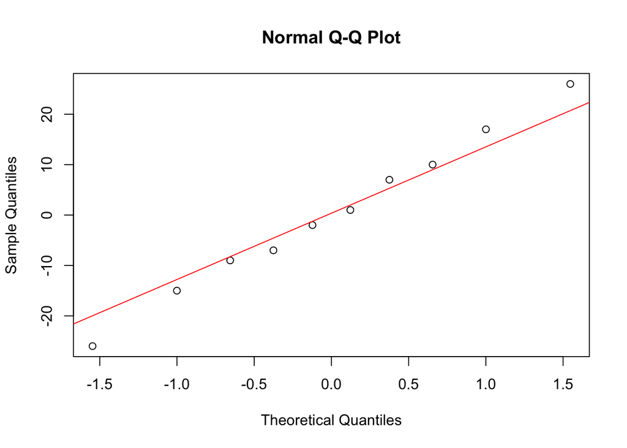

```r
qqnorm(Type1_Type2_Diff)
qqline(Type1_Type2_Diff, col = 'red')
```

There is 2 data points that are relativley fat from the data that follows the line realtiviley well, so the overall trend seems to be normally distributed.

#### **2.29 The Diameter of a ball bearing was measured by 12 inspectors, each using two different kinds of calipers. The results are as follows:**

```r
Inspector <- c(1,2,3,4,5,6,7,8,9,10,11,12)
Inspector
```

```
##  [1]  1  2  3  4  5  6  7  8  9 10 11 12
```

```r
Caliper_1<- c(.265,.265,.266,.267,.267,.265,.267,.267,.265,.268,.268,.265)
Caliper_1
```

```
##  [1] 0.265 0.265 0.266 0.267 0.267 0.265 0.267 0.267 0.265 0.268 0.268 0.265
```

```r
Caliper_2 <- c(.264,.265,.264,.266,.267,.268,.264,.265,.265,.267,.268,.269)
Caliper_2
```

```
##  [1] 0.264 0.265 0.264 0.266 0.267 0.268 0.264 0.265 0.265 0.267 0.268 0.269
```

**(a) Is there significant difference between the means of the population of measurements from which the two samples were selected? $\alpha=.05$**

$H_0 : \mu_1 = \mu_2$ $H_1 : \mu_1 \ne \mu_2$

```r
mean_caliper1 <- mean(Caliper_1)
mean_caliper1
```

```
## [1] 0.26625
```

```r
mean_caliper2<-mean(Caliper_2)
mean_caliper2
```

```
## [1] 0.266
```

```r
Caliper_Order_Diff = Caliper_1 - Caliper_2
t.test(Caliper_1,Caliper_2, paired = TRUE)
```

```
##
##  Paired t-test
##
## data:  Caliper_1 and Caliper_2
## t = 0.43179, df = 11, p-value = 0.6742
## alternative hypothesis: true difference in means is not equal to 0
## 95 percent confidence interval:
##  -0.001024344  0.001524344
## sample estimates:
## mean of the differences
##                 0.00025
```

No, there isn’t a significant diference between the mean of the following populations from the Calipers selected.

**(b) Find the P-value for the test in part (a)**

Due to the t.test we were given a p-value of 0.6742

**(c) Construct a 95 percent confidence Interval on the difference in mean diameter measurements for the two types of calipers.**

```r
t.test(Caliper_1,Caliper_2, paired = TRUE)
```

```
##
##  Paired t-test
##
## data:  Caliper_1 and Caliper_2
## t = 0.43179, df = 11, p-value = 0.6742
## alternative hypothesis: true difference in means is not equal to 0
## 95 percent confidence interval:
##  -0.001024344  0.001524344
## sample estimates:
## mean of the differences
##                 0.00025
```

As shown in our t.test output The 95% condidence interval of the mean diameter measurments for the two types of calipers is ( -0.001024344 0.001524344).